# HPM R learners - Summer 2020

#### Visualization Objects

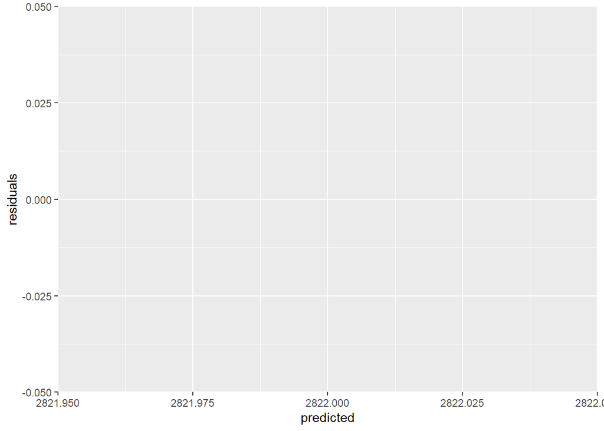

```r
# ggplot objects: just a list object round 2 (?) --------------------------

# this sets up our base graph
# if we print it, nothing will show up -- we haven't told ggplot HOW to graph yet
base <- ggplot(data=diamondsPlus,
               aes(x=predicted,
                   y=residuals))
base
```

```r
# base contains a bunch of stuff that ggplot uses to make the graph
# for example, the actual data and labels for those data
base$data
```

```
## # A tibble: 1 x 12
##   carat cut   color clarity depth table price     x     y     z predicted
##   <dbl> <ord> <ord> <ord>   <dbl> <dbl> <int> <dbl> <dbl> <dbl>     <dbl>
## 1   0.9 Good  J     VS2        64    61  2822  6.04  6.03  3.86      2822
## # ... with 1 more variable: residuals <dbl>
```

```r
base$labels
```

```
## $x
## [1] "predicted"
##
## $y
## [1] "residuals"
```

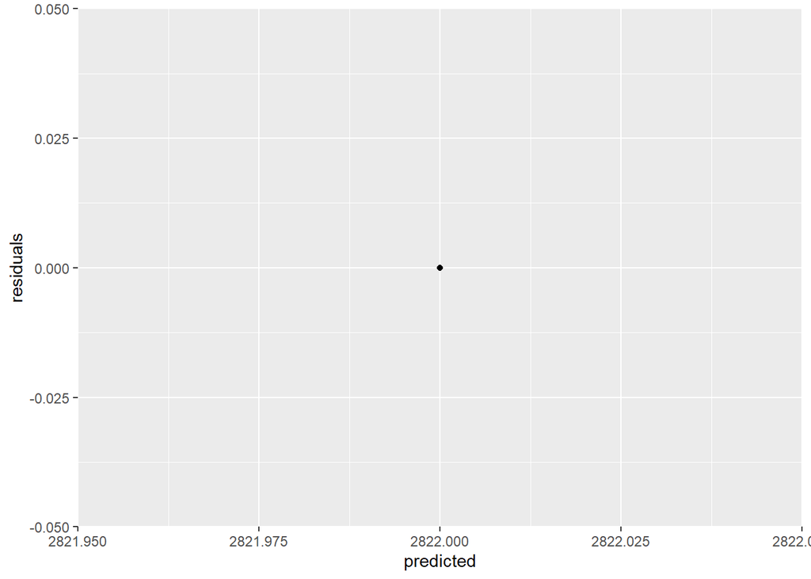

```r
# add points
base + geom_point()
```

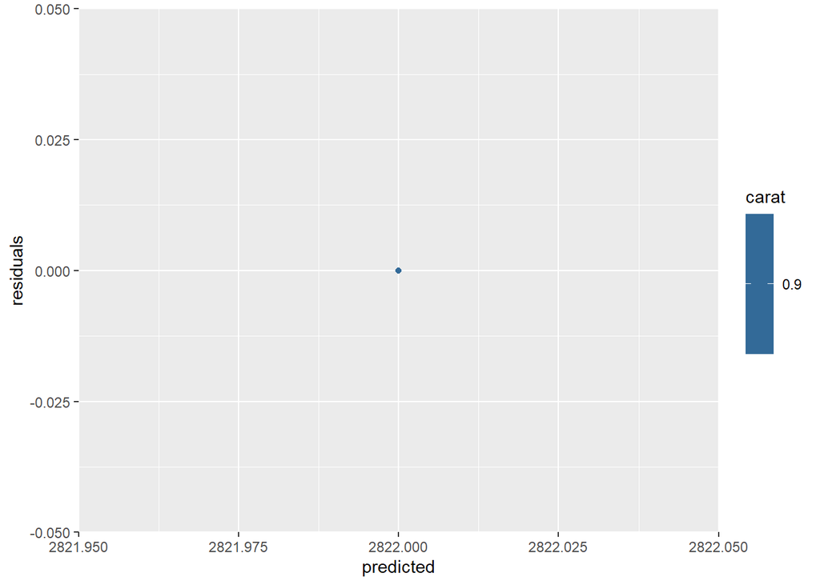

```r
# add points, and color by the carat (a little prelude to ggplot!)
base + geom_point(aes(color=carat))
```

### #3 - Data management

The main data management things we will cover by working through a (contrived) exercise together

- getting a sense of your data using `skimr`
- renaming variables: use `rename()` function in `tidyverse`
  - `rename()` keeps all variables
  - `rename(newVarName = oldVarName)`
- creating new variables: `mutate()`
  - `mutate(newvar = someCommand)`
  - use `if_else()` for if/else statements
  - use `case_when()` as a substitute for nested if/else statements
  - certain R functions that are not ‘vectorized’ cannot work over multiple columns (e.g., can’t take mean of col1 and col2 directly in `tidyverse`). You either need to write out (col1+col2)/2 by hand, or call `rowwise()` to explicitly tell R to perform everything on a row-by-row basis.
- subsetting data: `filter()`
  - this defines what ROWS you want to keep
- keeping and deleting variables/COLUMNS: `select()`
  - to drop variables, add them to the select function like so: `select(-age)`
  - to keep variables, do the same except take out the `-`
  - can keep all variables within a range by using a colon `select(var1:var10)`
  - can also use things like `starts_with()` and `ends_with()` which are very cool
  - can also rename ‘on-the-fly’ within a select statement using the same syntax as `rename()` above
- sorting data: `arrange()`
  - this will RESET row names, so make sure you always have a unique ID variable and are not relying on implicit dataset ordering
- importing and exporting data to a variety of file types/softwares (see section below for some examples)
  - `readxl` and `foreign` libraries have support for this
  - reading and writing csv files is done with `read_csv()` and `write_csv()` in base R
  - `File` > `Import Dataset` is actually very helpful for this
- options for transposing data: `pivot_longer()` and `pivot_wider()` (have not added examples of this, yet)

A few programming notes:

- R uses `&` (and); `|` (or)
- `is.na()` checks if that variable is NA (missing)
- can use `!` in front of `is.na()` to check if that variable is not missing
- The usual <, <=, >, >=
- use `%in%` function to avoid long strings of or statements
- use [pipes](https://r4ds.had.co.nz/pipes.html) when reasonable

#### Exercises / work though together

Use the diamonds dataset (will be loaded after you load tidyverse package)

- Skim the data
- Create a variable called `diamondID` using the `rownames_to_column()` function
- Sort data by `diamondID`
- Subset data to just those diamonds that are less than or equal to one carat, and cost less than $1,000
- Create two new variables that are **unordered** factor variables for diamond cut and color
  - While yes, these are technially ordered variables, if you try to use an ordered variable in a regression it will treat it as continuous, rather than create multiple indicators. Treating as continuous may be what you want, may not be. Just something to be aware of.
- Create a dichotomous variable equal to 1 if the diamonds color was rated D, E, or F, 0 otherwise
- Create a factor variable based on the previous dichotomous variable and give it nice value labels
- Use `table()` or `xtabs()` to check your derived variables
- Recreate depth variable (see `?diamonds` for the formula)
  - ah!! `mean()` doesn’t work 😭
  - this is because it’s not [vectorized](https://www.tidyverse.org/blog/2020/04/dplyr-1-0-0-rowwise/)
  - try it two ways - manually creating mean, and using `rowwise()`

#### Full code for exercises

```r
# today we'll use the diamonds dataset again

data(diamonds)

# I have been loving the 'skim' function from the skimr packages lately
# super easy and super high-level overview of your dataset
skimr::skim(diamonds)
```

Data summary

| Name | diamonds |
| --- | --- |
| Number of rows | 53940 |
| Number of columns | 10 |
| _______________________ |  |
| Column type frequency: |  |
| factor | 3 |
| numeric | 7 |
| ________________________ |  |
| Group variables | None |

**Variable type: factor**

| skim_variable | n_missing | complete_rate | ordered | n_unique | top_counts |
| --- | --- | --- | --- | --- | --- |
| cut | 0 | 1 | TRUE | 5 | Ide: 21551, Pre: 13791, Ver: 12082, Goo: 4906 |
| color | 0 | 1 | TRUE | 7 | G: 11292, E: 9797, F: 9542, H: 8304 |
| clarity | 0 | 1 | TRUE | 8 | SI1: 13065, VS2: 12258, SI2: 9194, VS1: 8171 |

**Variable type: numeric**

| skim_variable | n_missing | complete_rate | mean | sd | p0 | p25 | p50 | p75 | p100 | hist |
| --- | --- | --- | --- | --- | --- | --- | --- | --- | --- | --- |
| carat | 0 | 1 | 0.80 | 0.47 | 0.2 | 0.40 | 0.70 | 1.04 | 5.01 | ▇▂▁▁▁ |
| depth | 0 | 1 | 61.75 | 1.43 | 43.0 | 61.00 | 61.80 | 62.50 | 79.00 | ▁▁▇▁▁ |
| table | 0 | 1 | 57.46 | 2.23 | 43.0 | 56.00 | 57.00 | 59.00 | 95.00 | ▁▇▁▁▁ |
| price | 0 | 1 | 3932.80 | 3989.44 | 326.0 | 950.00 | 2401.00 | 5324.25 | 18823.00 | ▇▂▁▁▁ |
| x | 0 | 1 | 5.73 | 1.12 | 0.0 | 4.71 | 5.70 | 6.54 | 10.74 | ▁▁▇▃▁ |
| y | 0 | 1 | 5.73 | 1.14 | 0.0 | 4.72 | 5.71 | 6.54 | 58.90 | ▇▁▁▁▁ |
| z | 0 | 1 | 3.54 | 0.71 | 0.0 | 2.91 | 3.53 | 4.04 | 31.80 | ▇▁▁▁▁ |

```r
#library(tidylog)
diamondsLess <- diamonds %>%
  rownames_to_column(var="DiamondID") %>%
  arrange(DiamondID) %>%
  filter(carat<=1 & price < 1000) %>%
  mutate(cutF = factor(cut, ordered=FALSE),
         colorF = factor(color, ordered=FALSE),

         colorBest = if_else(condition = color %in% c("D", "E", "F"),
                             true = 1,
                             false = 0),
         colorBestF = factor(colorBest,
                             levels = c("0", "1"),
                             labels = c("0" = "0: not D/E/F",
                                        "1" = "1: best D/E/F")),

         cutIdeal = if_else(condition = cut=="Ideal",
                            true = "Ideal",
                            false = "Not ideal"))

xtabs(~cut + cutIdeal, data=diamondsLess, addNA = TRUE)
```

```
##            cutIdeal
## cut         Ideal Not ideal
##   Fair          0       111
##   Good          0      1110
##   Very Good     0      3240
##   Premium       0      3200
##   Ideal      6838         0
```

```r
xtabs(~color + colorBestF, data=diamondsLess, addNA = TRUE)
```

```
##      colorBestF
## color 0: not D/E/F 1: best D/E/F
##     D            0          2030
##     E            0          3038
##     F            0          2470
##     G         3170             0
##     H         2101             0
##     I         1228             0
##     J          462             0
```

```r
diamondsLess <- diamondsLess %>%

  mutate(meanCheck = (x+y)/2,
         depthCheck = (z/meanCheck)*100)
# this is a meh approach. i don't want to create intermediate variables
# and potentially make errors. why can't I just say mean(x,y)??? :(

# here's how you can!!
diamondsLess <- diamondsLess %>%
  rowwise() %>%
  mutate(depthCheck2 = (z/mean(c(x, y)))*100) %>%
  ungroup() #make sure to ungroup/unrowwise you data

# this may not look helpful now because we all know how to take an average manually
# but with more complex functions can be fantastic!

skimr::skim_without_charts(diamondsLess, depth, depthCheck, depthCheck2)
```

Data summary

| Name | diamondsLess |
| --- | --- |
| Number of rows | 14499 |
| Number of columns | 19 |
| _______________________ |  |
| Column type frequency: |  |
| numeric | 3 |
| ________________________ |  |
| Group variables | None |

**Variable type: numeric**

| skim_variable | n_missing | complete_rate | mean | sd | p0 | p25 | p50 | p75 | p100 |
| --- | --- | --- | --- | --- | --- | --- | --- | --- | --- |
| depth | 0 | 1 | 61.75 | 1.16 | 51.00 | 61.20 | 61.80 | 62.40 | 71.00 |
| depthCheck | 0 | 1 | 61.75 | 1.18 | 46.89 | 61.16 | 61.83 | 62.43 | 84.33 |
| depthCheck2 | 0 | 1 | 61.75 | 1.18 | 46.89 | 61.16 | 61.83 | 62.43 | 84.33 |

```r
# one caution: don't use rowwise() when you want to do something like making new factor variables

diamondsLess <- mutate(diamondsLess, clarityF1 = factor(clarity, ordered = FALSE))
str(diamondsLess$clarityF1)
```

```
##  Factor w/ 8 levels "I1","SI2","SI1",..: 2 5 1 1 3 7 7 2 7 7 ...
```

```r
diamondsLess <- diamondsLess %>%
  rowwise() %>%
  mutate(clarityF2 = factor(clarity, ordered = FALSE))
str(diamondsLess$clarityF2)
```

```
##  Factor w/ 8 levels "SI2","VS1","I1",..: 1 2 3 3 4 5 5 1 5 5 ...
```

```r
# it tried to make a factor variable *within each row* -- not what we wanted!!


#detach(package:tidylog)

# an aside on piping
# these are the same thing
# the first one is easier to read, yes?

# diamondsLess <- diamondsLess %>%
#   mutate(clarityF1 = factor(clarity, ordered = FALSE))
#
# diamondsLess <- mutate(diamondsLess,
#                        clarityF1 = factor(clarity, ordered = FALSE))
```

#### Import/Export

```r
# Importing / Exporting ---------------------------------------------------------------

ugly <- read.csv(here("data", "import-csv.csv"))
ugly
```

```
##       ï..TV.show      Actor..1 Channel netflix Number.of.Seasons X.1.show
## 1     the office steve carrell     nbc       1                 9      yes
## 2  parks and rec   amy poehler     nbc       1                 7      yes
## 3      community   joel mchale     nbc       1                 6      yes
## 4    brooklyn 99  andy samberg     nbc       0                 7      yes
## 5 the good place  kristen bell     nbc       1                 4      yes
## 6        30 rock      tina fey     nbc       0                 7      yes
```

```r
# janitor package is worth checking out
# "janitor has simple little tools for examining and cleaning dirty data."
pretty <- janitor::clean_names(ugly, case = "small_camel")
# case should be one of “snake”, “small_camel”, “big_camel”, “screaming_snake”, “parsed”, “mixed”,
# “lower_upper”, “upper_lower”, “swap”, “all_caps”, “lower_camel”, “upper_camel”, “internal_parsing”,
# “none”, “flip”, “sentence”, “random”, “title”


# this is the basic read excel format
rusersOrig <- readxl::read_excel(here("data", "R users group list 0527_136PM.xlsx"))
# add skip=# to skip the first # rows before reading in data


# can handle multiple sheets
sheets <- readxl::excel_sheets(here("data", "import-excel.xlsx"))

sheetsAsList <- lapply(sheets,
                       function(X) readxl::read_excel(here("data", "import-excel.xlsx"),
                                                      sheet = X))
names(sheetsAsList) <- sheets


# really only useful if yo uhave harmonized column names
fullResults <- bind_rows(sheetsAsList, .id = "column_label")

# extract individual results using the list syntax we learned earlier
teaTime <- sheetsAsList[["tea time"]]
tv <- sheetsAsList[["shows"]]
# tv's names look prettier, but they are still weird and need ``. for example:
names(tv)
```

```
## [1] "TV show"           "Actor #1"          "Channel"
## [4] "netflix"           "Number of Seasons" "#1 show"
```

```r
tv <- janitor::clean_names(tv, case="lower_camel")
names(tv)
```

```
## [1] "tvShow"          "actorNumber1"    "channel"         "netflix"
## [5] "numberOfSeasons" "number1Show"
```

```r
# to import stata, best to use haven library
stataHaven <- haven::read_dta(here("data", "stata-nlsw.dta"))

# foreign requires stata 5-12 only :(
# stataForeign <- foreign::read.dta(here("data", "stata-nlsw.dta"))
# new package for 13-current
# https://cran.r-project.org/web/packages/readstata13/readme/README.html

# you can also write stata/SAS data directly

# this does not seem to work very well with the TV dataset because it has some characters with spaces
# probably best for those kinds of data to use a CSV file so you can wrap strings in quotations
foreign::write.foreign(teaTime,
                       datafile = here("data", "stata-data.txt"),
                       codefile = here("data", "stata-import.do"),
                       package = "Stata")


foreign::write.foreign(df = teaTime,
                       datafile = here("data", "sas-data.txt"),
                       codefile = here("data", "sas-import.sas"),
                       package = "SAS",
                       dataname = "rlearners")
```

### #4 - Visualization 1.0

Quick review of 1) any data management questions, and 2) import/export code from last session.

Plotting things to cover:

- Base vs. ggplot
  - base does not require any additional packages to be used
    - `plot()` is for scatterplot
    - `hist()` for histogram
    - any conditional or group coloring, superimposing lines and dots, etc. gets very difficult within base (I think)
  - [ggplot](https://ggplot2.tidyverse.org/) is the workhorse that most all of us will want to use
    - graph multiple relationships on one plot
    - almost endlessly customizable
    - colors, etc.
- ggplot basics
  - “It’s hard to succinctly describe how ggplot2 works because it embodies a deep philosophy of visualisation. However, in most cases you start with ggplot(), supply a dataset and aesthetic mapping (with aes()). You then add on layers (like geom_point() or geom_histogram()), scales (like scale_colour_brewer()), faceting specifications (like facet_wrap()) and coordinate systems (like coord_flip()).” from [here](https://ggplot2.tidyverse.org/)
  - format for data – grouping variable should be in columns
  - aesthetics – what will be displayed
    - x and y (usually will always be used)
    - fill = inside color, color = outside color
    - alpha = transparency
    - size = size of point, line thickness, etc.
    - shape of points, stroke (outside line), and i’m sure many others
  - geoms – how those aesthetics are displayed
    - geom_point() for scatterplot
    - geom_line() for lines
    - geom_density() for density plots
    - geom_bar() for bar charts
    - geom_histogram() for histograms
    - many, many others

Example plots to make:

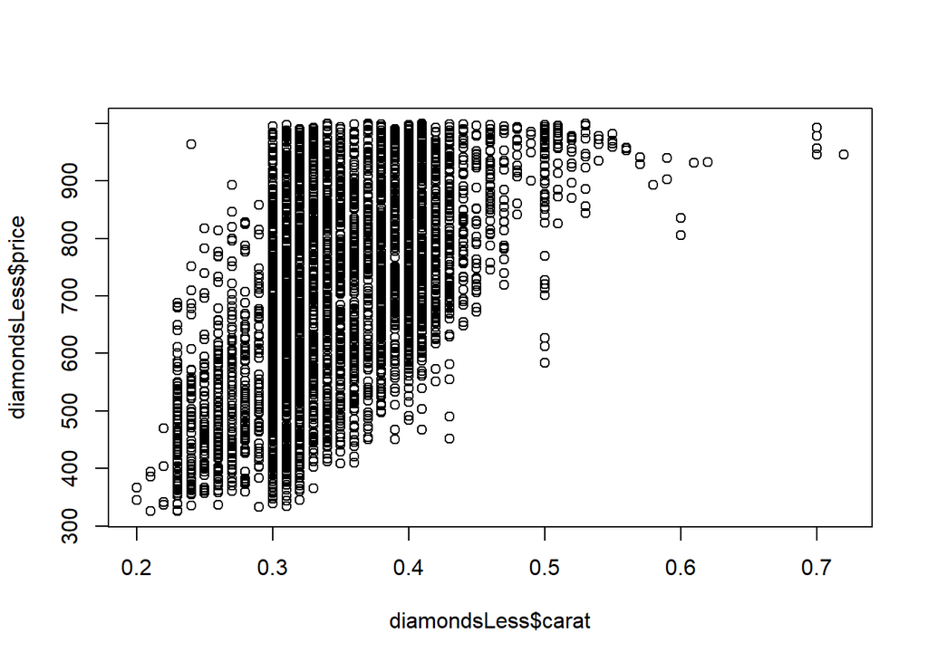

```r
# data(diamonds)

# use the diamondsLess dataset from last week as review of commands, and cut down on number of points we have to plot


# these two things look exactly the same.
# some people prefer base R for speed
# but I don't think it can beat ggplot for customizability
# (some people might argue)
# I use base plotting sometimes for 1) quick-and-dirty plots, or 2) network visualization
plot(x = diamondsLess$carat,
     y = diamondsLess$price)
```

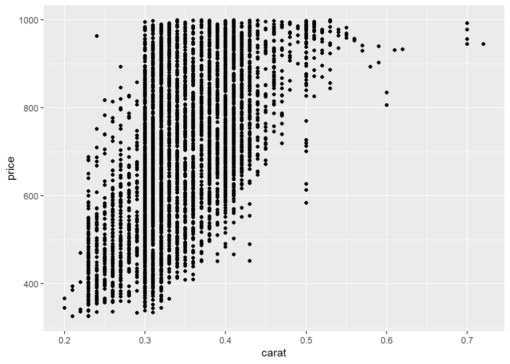

```r
ggplot(data=diamondsLess,
       aes(x=carat,
           y=price)) +
  geom_point()
```

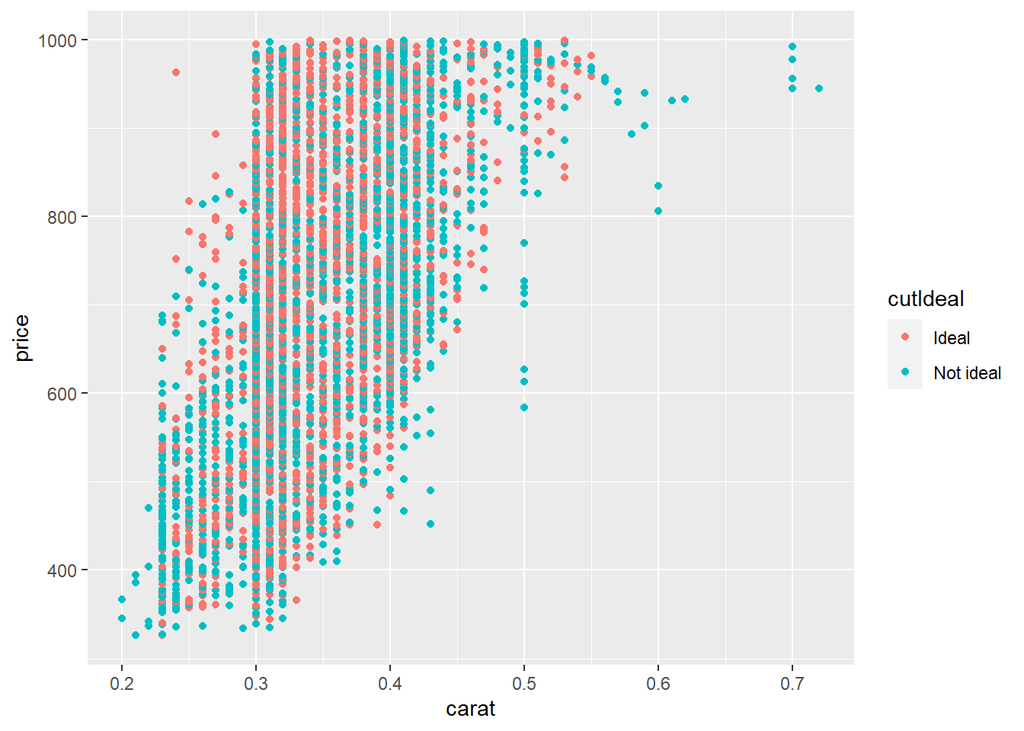

```r
ggsave(filename = here("output", "testSave.png"),
       plot = last_plot(),
       device = "png",
       dpi = 500,
       width = 8,
       height = 7,
       units = "in")


# exercise 1
ggplot(data=diamondsLess,
       aes(x=carat,
           y=price)) +
  geom_point(aes(color = cutIdeal))
```

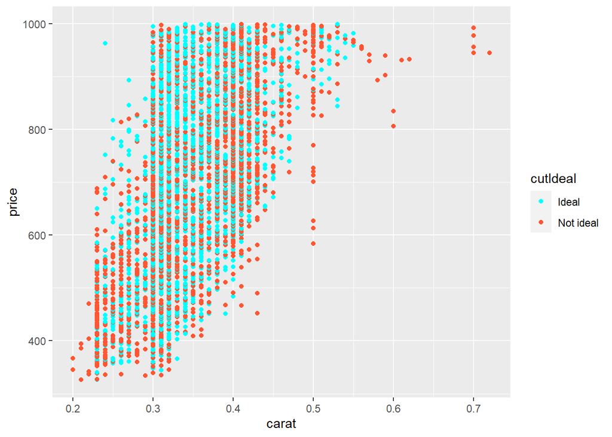

```r
# exercise 2
ggplot(data=diamondsLess,
       aes(x=carat,
           y=price)) +
  geom_point(aes(color = cutIdeal)) +
  #scale_color_nejm()
  #scale_color_viridis_d()
  scale_color_manual(values = c("Ideal" = "#00FFFF",
                                "Not ideal" = "#FF5733"))
```

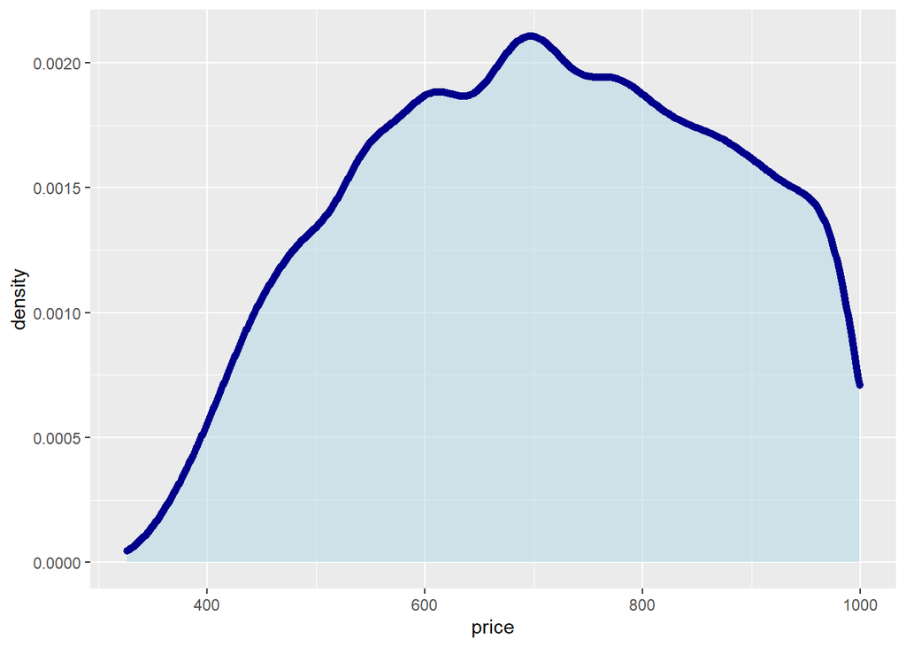

```r
# exercise 3
ggplot(data=diamondsLess,
       aes(x=price)) +
  geom_density(color = "darkblue",
               size=2,
               fill = "lightblue",
               alpha = 0.5)
```

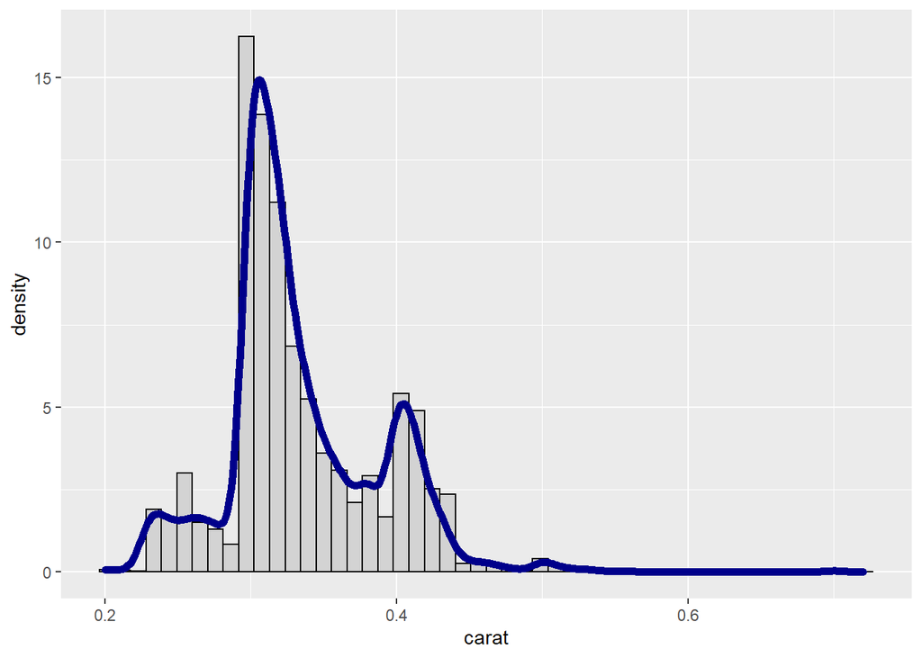

```r
# exercise 4 & 5
ggplot(data=diamondsLess) +
  geom_histogram(aes(x=carat,
                     y=..density..),
                 bins = 50,
                 color = "black",
                 fill = "lightgray") +
  geom_density(aes(x=carat), color = "darkblue", size=2)
```

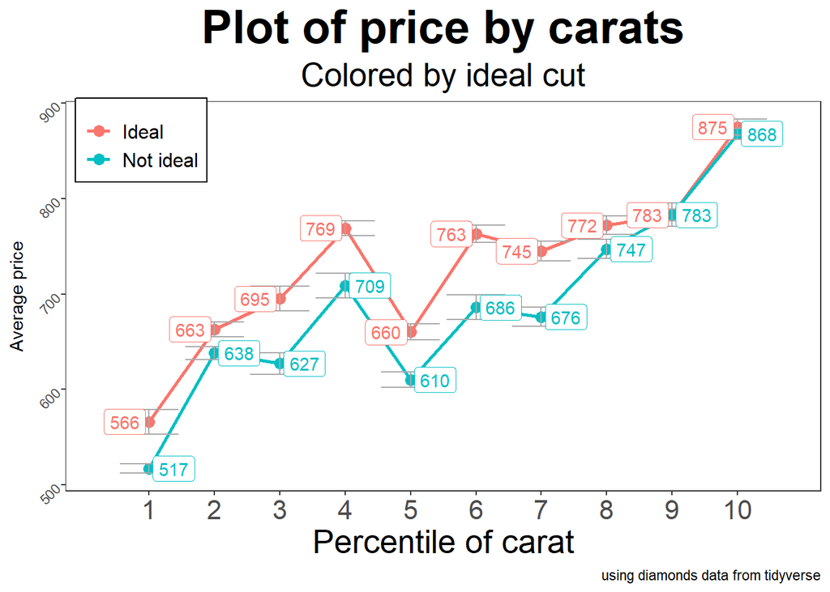

```r
# exercise 6
diamondsLess <- ungroup(diamondsLess)


diamondsMean <- diamondsLess %>%
  arrange(carat) %>%
  mutate(carat10pct = ntile(x = carat, n=10)) %>%
  group_by(carat10pct, cutIdeal) %>%
  summarise(priceMean = mean(price),
            priceSD = sd(price),
            priceN = n(),

            .groups = "keep") %>%
  ungroup() %>%
  mutate(priceMean = round(priceMean, digits=0),
         priceSE = priceSD/priceN,
         priceLL = priceMean - (50*priceSE),
         priceUL = priceMean + (50*priceSE))



ggplot(data=diamondsMean,
       aes(x=carat10pct,
           y=priceMean,
           group=cutIdeal,
           color=cutIdeal)) +
  geom_line(size=1) +
  geom_point(size=3) +
  geom_errorbar(aes(ymin = priceLL,
                    ymax = priceUL),
                color = "darkgray") +
  geom_label(aes(label = priceMean), show.legend = FALSE, position = position_dodge(width=1.5)) +
  scale_x_continuous(breaks = c(1,2,3,4,5,6,7,8,9,10)) +
  labs(title = "Plot of price by carats",
       subtitle = "Colored by ideal cut",
       caption = "using diamonds data from tidyverse") +
  xlab("Percentile of carat") +
  ylab("Average price") +
  theme_bw() +
  theme(legend.position = c(0.1,0.9),
        legend.background = element_rect(linetype = "solid", colour = "black"),
        legend.title = element_blank(),
        panel.grid = element_blank(),
        axis.text.x = element_text(size=16),
        axis.title.x = element_text(size=20),
        legend.text = element_text(size=12),
        plot.title = element_text(size=28, face="bold", hjust = 0.5),
        plot.subtitle = element_text(size=20, hjust=0.5),
        axis.text.y = element_text(angle=45))
```

### #5 - Visualization 2.0

**our work from today is in the same codeblock as Visualization 1.0**

- Review from last week
  - update on group_by !!
- [Faceting](https://ggplot2.tidyverse.org/reference/facet_grid.html) - repeating graph for level(s) of variable(s)
- Modifying components of a theme
  - title, subtitle, caption, axis labels
  - overall ggplot [themes](https://ggplot2.tidyverse.org/reference/ggtheme.html)
  - see Andrew Heiss tutorial below for help with themes too
  - Use exercise #6 from last week to practice modifying components of a theme
    - where legend is (and removing legend)
    - remove legend title
    - axis ticks
    - axis lengths
- Save ggplots using `ggsave()` function
- Fun geoms
  - violin plots
  - dotplots (underutilized, I think!)
- can use `ggsave()` to save png, pdf, etc.
  - note that the R plot pane will auto-adjust based on size, so its best to work with the exported files and make sure those look the way you want them. nothing more frustrating than making something look good in the plot window but looking horrid when you export it.

Additional plotting resources:

- Colors:
  - `ggsci`: color palettes matching major journals [here](https://nanx.me/ggsci/articles/ggsci.html)
  - `Rcolorbrewer`: major package with many palettes [here](https://www.r-graph-gallery.com/38-rcolorbrewers-palettes.html). Note sequential, diverging, and qualitative palette types!
  - R color names [here](http://www.stat.columbia.edu/~tzheng/files/Rcolor.pdf). Can also type `colors()` to see all names.
  - Can also use hexadecimal color codes in R - make sure to put in quotes
- *Very good* `ggplot` intro by [Andrew Heiss](https://twitter.com/andrewheiss) [here](https://datavizm20.classes.andrewheiss.com/). Also some `tidyverse` but not enough to fully understand it
- mapping aesthetics [cheat sheet](https://drive.google.com/file/d/1Dvul1p6TYH6gWJzZRwpE0YX1dO0hDF-b/view)

### #6 - More data management

- joining
  - documentation classifies joins in three ways - mutating, filtering, and nesting. mutating is the most common, especially for our type of work (generally)
  - mutating
    - `left_join()`: prioritizes the *left hand side* data frame (‘prioritizes’ means it returns those rows)
    - `full_join()`: keeps all rows from both data frames
    - there’s also `right_join()` and `inner_join()` that have similar behavior
  - filtering
    - used to keep cases from the ‘left hand’ dataframe. `semi_join()` and `anti_join()`
  - nesting
    - ‘creates a list column of data.frames()’. i’ve never used this!
- transposing - `pivot_wider()` and `pivot_longer()`
- begin descriptives if time – `tableone()` package

Exercises:

- import excel data (use here function)
- join patronus data to characters data
  1. first join the id data to characters, by Name (join variable called Name in both datasets)
  2. use abbrev variable to add patronus data (join variable named differently in each dataset)
- keep only those characters who are in one of the four Hogwarts houses
- create a new variable that =1 if a character is female, =0 if male
- group by hogwarts house
  - count the number of people in each Hogwarts house
  - calculate the proportion of women in each hogwarts house
- tranposing - take character data and make it ‘longer’, then go back ‘wider’
- package mentions - tidylog and tidyselect

```r
library(readxl)
library(tidylog)
# links character name to short abbreviation
id <- read_excel(here("data", "hp", "ids.xlsx"))

# contains lots of information on characters, like wand length etc.
characters <- read_excel(here("data", "hp", "characters.xlsx"))

# dataset just containing patronus forms for the characters who produced a 'corporeal' patronus
patronus <- read_excel(here("data", "hp", "patronus.xlsx"))



characterIDleft <- left_join(characters, id,
                             by="Name",
                             suffix = c("_character", "_ID"))
```

```
## left_join: added 3 columns (Id_character, Id_ID, abbrev)
```

```
##            > rows only in x     0
```

```
##            > rows only in y  (  0)
```

```
##            > matched rows     140
```

```
##            >                 =====
```

```
##            > rows total       140
```

```r
#characterIDfull <- full_join(characters, id, by="Name")
#identical(characterIDleft, characterIDfull)


# keeps all 140 rows
addPatronus <- left_join(characterIDleft, patronus,
                         by = c("abbrev" = "character"))
```

```
## left_join: added one column (Patronus)
```

```
##            > rows only in x   119
```

```
##            > rows only in y  (  0)
```

```
##            > matched rows      21
```

```
##            >                 =====
```

```
##            > rows total       140
```

```r
# say we only wanted the characters in the patronus dataset
# two ways to keep only 21 in patronus dataset
# there are also other ways with more pre-processing (like filtering, etc.)
# but I think this is the most straightforward way
addPatronusv2 <- right_join(characterIDleft, patronus,
                            by = c("abbrev" = "character"))
```

```
## right_join: added one column (Patronus)
```

```
##             > rows only in x  (119)
```

```
##             > rows only in y     0
```

```
##             > matched rows      21
```

```
##             >                 =====
```

```
##             > rows total        21
```

```r
# same result can be achieved by left_join and switching datasets
addPatronusv3 <- left_join(patronus, characterIDleft,
                            by = c("character" = "abbrev"))
```

```
## left_join: added 15 columns (Id_character, Name, Gender, Job, House, …)
```

```
##            > rows only in x     0
```

```
##            > rows only in y  (119)
```

```
##            > matched rows      21
```

```
##            >                 =====
```

```
##            > rows total        21
```

```r
#identical(addPatronusv2, addPatronusv3)
#note they are not technically 'identical' because the columns are not in the same order, reflecting the different merge order

# using the pipe operator to chain all of this together
addPatronusv4 <- characters %>%

  left_join(id,
            by = "Name",
            suffix = c("_character", "_ID")) %>%

  left_join(patronus,
            by = c("abbrev" = "character")) %>%

  filter(House %in% c("Gryffindor", "Hufflepuff", "Ravenclaw", "Slytherin")) %>%

  mutate(gender01 = if_else(Gender=="Female", 1, 0))
```

```
## left_join: added 3 columns (Id_character, Id_ID, abbrev)
```

```
##            > rows only in x     0
```

```
##            > rows only in y  (  0)
```

```
##            > matched rows     140
```

```
##            >                 =====
```

```
##            > rows total       140
```

```
## left_join: added one column (Patronus)
```

```
##            > rows only in x   119
```

```
##            > rows only in y  (  0)
```

```
##            > matched rows      21
```

```
##            >                 =====
```

```
##            > rows total       140
```

```
## filter: removed 43 rows (31%), 97 rows remaining
```

```
## mutate: new variable 'gender01' (double) with 3 unique values and 1% NA
```

```r
# can continue with pipe operator in the above statement, but I prefer to keep grouped things separate
# splitting up the pipe pieces can help with debugging and code flow
grouped <- addPatronusv4 %>%

  group_by(House) %>%

  summarise(numberInHouse = n(),
            propFemale = round(mean(gender01, na.rm = TRUE), digits=2),
            numFemale = sum(gender01, na.rm = TRUE),
            numNAGender = sum(is.na(gender01)),
            .groups="drop") # can specify "keep" if you want the data to remain 'grouped' in R's memory
```

```
## group_by: one grouping variable (House)
```

```
## summarise: now 4 rows and 5 columns, ungrouped
```

```r
# transposing
longCharacters <- pivot_longer(data = (characters %>% select(Name, Gender, Wand)),
                               cols = c(Gender, Wand),
                               names_to = "characteristic")
```

```
## select: dropped 11 variables (Id, Job, House, Species, Blood status, …)
```

```
## pivot_longer: reorganized (Gender, Wand) into (characteristic, value) [was 140x3, now 280x3]
```

```r
# will match to all rows
longPlusAbbrev <- left_join(longCharacters, (id %>% select(Name, abbrev)),
                            by = "Name")
```

```
## select: dropped one variable (Id)
```

```
## left_join: added one column (abbrev)
```

```
##            > rows only in x     0
```

```
##            > rows only in y  (  0)
```

```
##            > matched rows     280
```

```
##            >                 =====
```

```
##            > rows total       280
```

```r
# let's take this data and go wider now
wider <- pivot_wider(longPlusAbbrev,
                     id_cols = c(Name, abbrev),
                     names_from = characteristic)
```

```
## pivot_wider: reorganized (characteristic, value) into (Gender, Wand) [was 280x4, now 140x4]
```

```r
# descriptives

library(tableone)

contVar <- c("Id_character")
catVar <- c("Gender", "House", "Loyalty")

# use addPatronusv4 - restricted to just 4 hogwarts houses

CreateTableOne(vars = c(contVar, catVar),
               data=addPatronusv4,
               factorVars = catVar)
```

```
##
##                                                                                                               Overall
##   n                                                                                                              97
##   Id_character (mean (SD))                                                                                    52.04 (33.35)
##   Gender = Male (%)                                                                                              64 (66.7)
##   House (%)
##      Gryffindor                                                                                                  38 (39.2)
##      Hufflepuff                                                                                                  13 (13.4)
##      Ravenclaw                                                                                                   18 (18.6)
##      Slytherin                                                                                                   28 (28.9)
##   Loyalty (%)
##      Albus Dumbledore | Dumbledore's Army | Order of the Phoenix | Hogwarts School of Witchcraft and Wizardry     1 ( 1.7)
##      Albus Dumbledore | Order of the Phoenix | Hogwarts School of Witchcraft and Wizardry                         2 ( 3.4)
##      Dumbledore's Army                                                                                            6 (10.2)
##      Dumbledore's Army | Hogwarts School of Witchcraft and Wizardry                                               2 ( 3.4)
##      Dumbledore's Army | Order of the Phoenix | Hogwarts School of Witchcraft and Wizardry                        8 (13.6)
##      Dumbledore's Army |Hogwarts School of Witchcraft and Wizardry                                               14 (23.7)
##      Hogwarts School of Witchcraft and Wizardry                                                                   1 ( 1.7)
##      Lord Voldemort                                                                                               1 ( 1.7)
##      Lord Voldemort  | Death Eaters                                                                              10 (16.9)
##      Lord Voldemort| Death Eaters                                                                                 1 ( 1.7)
##      Ministry of Magic                                                                                            1 ( 1.7)
##      Ministry of Magic | Order of the Phoenix                                                                     1 ( 1.7)
##      Order of the Phoenix                                                                                         6 (10.2)
##      Order of the Phoenix | Gringotts Wizarding Bank                                                              1 ( 1.7)
##      Order of the Phoenix| British Ministry of Magic                                                              1 ( 1.7)
##      Order of the Phoenix| Hogwarts School of Witchcraft and Wizardry |British Ministry of Magic                  1 ( 1.7)
##      Original Order of the Phoenix                                                                                2 ( 3.4)
```

```r
tmp <- CreateTableOne(vars = c(contVar, catVar),
               data=addPatronusv4,
               factorVars = catVar,
               strata="House",
               test = FALSE)
tmp1 <- print(tmp)
```

```
##                                                                                                              Stratified by House
##                                                                                                               Gryffindor
##   n                                                                                                              38
##   Id_character (mean (SD))                                                                                    30.18 (34.73)
##   Gender = Male (%)                                                                                              26 ( 68.4)
##   House (%)
##      Gryffindor                                                                                                  38 (100.0)
##      Hufflepuff                                                                                                   0 (  0.0)
##      Ravenclaw                                                                                                    0 (  0.0)
##      Slytherin                                                                                                    0 (  0.0)
##   Loyalty (%)
##      Albus Dumbledore | Dumbledore's Army | Order of the Phoenix | Hogwarts School of Witchcraft and Wizardry     1 (  2.9)
##      Albus Dumbledore | Order of the Phoenix | Hogwarts School of Witchcraft and Wizardry                         2 (  5.9)
##      Dumbledore's Army                                                                                            1 (  2.9)
##      Dumbledore's Army | Hogwarts School of Witchcraft and Wizardry                                               2 (  5.9)
##      Dumbledore's Army | Order of the Phoenix | Hogwarts School of Witchcraft and Wizardry                        8 ( 23.5)
##      Dumbledore's Army |Hogwarts School of Witchcraft and Wizardry                                                8 ( 23.5)
##      Hogwarts School of Witchcraft and Wizardry                                                                   1 (  2.9)
##      Lord Voldemort                                                                                               0 (  0.0)
##      Lord Voldemort  | Death Eaters                                                                               0 (  0.0)
##      Lord Voldemort| Death Eaters                                                                                 1 (  2.9)
##      Ministry of Magic                                                                                            0 (  0.0)
##      Ministry of Magic | Order of the Phoenix                                                                     0 (  0.0)
##      Order of the Phoenix                                                                                         6 ( 17.6)
##      Order of the Phoenix | Gringotts Wizarding Bank                                                              1 (  2.9)
##      Order of the Phoenix| British Ministry of Magic                                                              1 (  2.9)
##      Order of the Phoenix| Hogwarts School of Witchcraft and Wizardry |British Ministry of Magic                  1 (  2.9)
##      Original Order of the Phoenix                                                                                1 (  2.9)
##                                                                                                              Stratified by House
##                                                                                                               Hufflepuff
##   n                                                                                                              13
##   Id_character (mean (SD))                                                                                    89.46 (14.41)
##   Gender = Male (%)                                                                                               8 ( 61.5)
##   House (%)
##      Gryffindor                                                                                                   0 (  0.0)
##      Hufflepuff                                                                                                  13 (100.0)
##      Ravenclaw                                                                                                    0 (  0.0)
##      Slytherin                                                                                                    0 (  0.0)
##   Loyalty (%)
##      Albus Dumbledore | Dumbledore's Army | Order of the Phoenix | Hogwarts School of Witchcraft and Wizardry     0 (  0.0)
```

[output cut: 57 more lines]

```
##      Dumbledore's Army                                                                                            0 (  0.0)
##      Dumbledore's Army | Hogwarts School of Witchcraft and Wizardry                                               0 (  0.0)
##      Dumbledore's Army | Order of the Phoenix | Hogwarts School of Witchcraft and Wizardry                        0 (  0.0)
##      Dumbledore's Army |Hogwarts School of Witchcraft and Wizardry                                                0 (  0.0)
##      Hogwarts School of Witchcraft and Wizardry                                                                   0 (  0.0)
##      Lord Voldemort                                                                                               0 (  0.0)
##      Lord Voldemort  | Death Eaters                                                                              10 ( 90.9)
##      Lord Voldemort| Death Eaters                                                                                 0 (  0.0)
##      Ministry of Magic                                                                                            1 (  9.1)
##      Ministry of Magic | Order of the Phoenix                                                                     0 (  0.0)
##      Order of the Phoenix                                                                                         0 (  0.0)
##      Order of the Phoenix | Gringotts Wizarding Bank                                                              0 (  0.0)
##      Order of the Phoenix| British Ministry of Magic                                                              0 (  0.0)
##      Order of the Phoenix| Hogwarts School of Witchcraft and Wizardry |British Ministry of Magic                  0 (  0.0)
##      Original Order of the Phoenix                                                                                0 (  0.0)
```

```r
xlsx::write.xlsx(tmp1, file=here("output", "t1HP.xlsx"))
```

### #7 Descriptives & Table-making

- Descriptive statistics in R
  - There are many, many packages - how to choose?
  - Getting basic descriptive statistics
    - `skimr` - I think this is the most basic of descriptive packages, and I like how I can get an overview of both missing data and summary stats. Not sure about its use for stratified descriptives and/or exporting to other software.
    - `desctable` - this is a newer package. I am still figuring it all out, but it seems like it can finally do everything I want in a descriptive stats package. Vignette about its use [here](https://cran.r-project.org/web/packages/desctable/vignettes/desctable.html)
    - `tableone` - I find this a very annoying package but it usually gets the job done
  - Missing data with `naniar` package
- Exporting to excel and linking spreadsheets - export raw descriptives from R, link to a formatted excel sheet, update as needed.

```r
data(diamonds)

descriptiveDiamonds <- diamonds %>%

  #dplyr::slice_sample(n=150) %>%

  rownames_to_column(var="number") %>%

  # introducing some NA's to make this more realistic
  mutate(carat = if_else(number %in% c(1,2,3,56,34,89,65,22,31,124,118),
                         as.numeric(NA),
                         carat),

         colorBest = if_else(condition = color %in% c("D", "E", "F"),
                             true = 1,
                             false = 0),
         colorBestF = factor(colorBest,
                             levels = c("0", "1"),
                             labels = c("0" = "0: not D/E/F",
                                        "1" = "1: best D/E/F"))
         )
```

```
## mutate: changed 11 values (<1%) of 'carat' (11 new NA)
```

```
##         new variable 'colorBest' (double) with 2 unique values and 0% NA
```

```
##         new variable 'colorBestF' (factor) with 2 unique values and 0% NA
```

```r
rm(diamonds)




# PACKAGE #1: SKIMR
library(skimr)
skim(descriptiveDiamonds)
```

Data summary

| Name | descriptiveDiamonds |
| --- | --- |
| Number of rows | 53940 |
| Number of columns | 13 |
| _______________________ |  |
| Column type frequency: |  |
| character | 1 |
| factor | 4 |
| numeric | 8 |
| ________________________ |  |
| Group variables | None |

**Variable type: character**

| skim_variable | n_missing | complete_rate | min | max | empty | n_unique | whitespace |
| --- | --- | --- | --- | --- | --- | --- | --- |
| number | 0 | 1 | 1 | 5 | 0 | 53940 | 0 |

**Variable type: factor**

| skim_variable | n_missing | complete_rate | ordered | n_unique | top_counts |
| --- | --- | --- | --- | --- | --- |
| cut | 0 | 1 | TRUE | 5 | Ide: 21551, Pre: 13791, Ver: 12082, Goo: 4906 |
| color | 0 | 1 | TRUE | 7 | G: 11292, E: 9797, F: 9542, H: 8304 |
| clarity | 0 | 1 | TRUE | 8 | SI1: 13065, VS2: 12258, SI2: 9194, VS1: 8171 |
| colorBestF | 0 | 1 | FALSE | 2 | 0: : 27826, 1: : 26114 |

**Variable type: numeric**

| skim_variable | n_missing | complete_rate | mean | sd | p0 | p25 | p50 | p75 | p100 | hist |
| --- | --- | --- | --- | --- | --- | --- | --- | --- | --- | --- |
| carat | 11 | 1 | 0.80 | 0.47 | 0.2 | 0.40 | 0.70 | 1.04 | 5.01 | ▇▂▁▁▁ |
| depth | 0 | 1 | 61.75 | 1.43 | 43.0 | 61.00 | 61.80 | 62.50 | 79.00 | ▁▁▇▁▁ |
| table | 0 | 1 | 57.46 | 2.23 | 43.0 | 56.00 | 57.00 | 59.00 | 95.00 | ▁▇▁▁▁ |
| price | 0 | 1 | 3932.80 | 3989.44 | 326.0 | 950.00 | 2401.00 | 5324.25 | 18823.00 | ▇▂▁▁▁ |
| x | 0 | 1 | 5.73 | 1.12 | 0.0 | 4.71 | 5.70 | 6.54 | 10.74 | ▁▁▇▃▁ |
| y | 0 | 1 | 5.73 | 1.14 | 0.0 | 4.72 | 5.71 | 6.54 | 58.90 | ▇▁▁▁▁ |
| z | 0 | 1 | 3.54 | 0.71 | 0.0 | 2.91 | 3.53 | 4.04 | 31.80 | ▇▁▁▁▁ |
| colorBest | 0 | 1 | 0.48 | 0.50 | 0.0 | 0.00 | 0.00 | 1.00 | 1.00 | ▇▁▁▁▇ |

```r
# no histograms
skim_without_charts(descriptiveDiamonds)
```

Data summary

| Name | descriptiveDiamonds |
| --- | --- |
| Number of rows | 53940 |
| Number of columns | 13 |
| _______________________ |  |
| Column type frequency: |  |
| character | 1 |
| factor | 4 |
| numeric | 8 |
| ________________________ |  |
| Group variables | None |

**Variable type: character**

| skim_variable | n_missing | complete_rate | min | max | empty | n_unique | whitespace |
| --- | --- | --- | --- | --- | --- | --- | --- |
| number | 0 | 1 | 1 | 5 | 0 | 53940 | 0 |

**Variable type: factor**

| skim_variable | n_missing | complete_rate | ordered | n_unique | top_counts |
| --- | --- | --- | --- | --- | --- |
| cut | 0 | 1 | TRUE | 5 | Ide: 21551, Pre: 13791, Ver: 12082, Goo: 4906 |
| color | 0 | 1 | TRUE | 7 | G: 11292, E: 9797, F: 9542, H: 8304 |
| clarity | 0 | 1 | TRUE | 8 | SI1: 13065, VS2: 12258, SI2: 9194, VS1: 8171 |
| colorBestF | 0 | 1 | FALSE | 2 | 0: : 27826, 1: : 26114 |

**Variable type: numeric**

| skim_variable | n_missing | complete_rate | mean | sd | p0 | p25 | p50 | p75 | p100 |
| --- | --- | --- | --- | --- | --- | --- | --- | --- | --- |
| carat | 11 | 1 | 0.80 | 0.47 | 0.2 | 0.40 | 0.70 | 1.04 | 5.01 |
| depth | 0 | 1 | 61.75 | 1.43 | 43.0 | 61.00 | 61.80 | 62.50 | 79.00 |
| table | 0 | 1 | 57.46 | 2.23 | 43.0 | 56.00 | 57.00 | 59.00 | 95.00 |
| price | 0 | 1 | 3932.80 | 3989.44 | 326.0 | 950.00 | 2401.00 | 5324.25 | 18823.00 |
| x | 0 | 1 | 5.73 | 1.12 | 0.0 | 4.71 | 5.70 | 6.54 | 10.74 |
| y | 0 | 1 | 5.73 | 1.14 | 0.0 | 4.72 | 5.71 | 6.54 | 58.90 |
| z | 0 | 1 | 3.54 | 0.71 | 0.0 | 2.91 | 3.53 | 4.04 | 31.80 |
| colorBest | 0 | 1 | 0.48 | 0.50 | 0.0 | 0.00 | 0.00 | 1.00 | 1.00 |

```r
# just a few variables
skim_without_charts(descriptiveDiamonds %>% group_by(colorBestF) %>% select(colorBestF, carat, cut, price))
```

```
## group_by: one grouping variable (colorBestF)
```

```
## select: dropped 9 variables (number, color, clarity, depth, table, …)
```

Data summary

| Name | %>%(…) |
| --- | --- |
| Number of rows | 53940 |
| Number of columns | 4 |
| _______________________ |  |
| Column type frequency: |  |
| factor | 1 |
| numeric | 2 |
| ________________________ |  |
| Group variables | colorBestF |

**Variable type: factor**

| skim_variable | colorBestF | n_missing | complete_rate | ordered | n_unique | top_counts |
| --- | --- | --- | --- | --- | --- | --- |
| cut | 0: not D/E/F | 0 | 1 | TRUE | 5 | Ide: 10988, Pre: 7520, Ver: 6005, Goo: 2402 |
| cut | 1: best D/E/F | 0 | 1 | TRUE | 5 | Ide: 10563, Pre: 6271, Ver: 6077, Goo: 2504 |

**Variable type: numeric**

| skim_variable | colorBestF | n_missing | complete_rate | mean | sd | p0 | p25 | p50 | p75 | p100 |
| --- | --- | --- | --- | --- | --- | --- | --- | --- | --- | --- |
| carat | 0: not D/E/F | 4 | 1 | 0.90 | 0.53 | 0.23 | 0.41 | 0.84 | 1.2 | 5.01 |
| carat | 1: best D/E/F | 7 | 1 | 0.69 | 0.38 | 0.20 | 0.38 | 0.56 | 1.0 | 3.40 |
| price | 0: not D/E/F | 0 | 1 | 4491.23 | 4305.09 | 334.00 | 998.00 | 3070.00 | 6334.0 | 18823.00 |
| price | 1: best D/E/F | 0 | 1 | 3337.76 | 3527.05 | 326.00 | 919.00 | 1938.50 | 4372.0 | 18791.00 |

```r
# PACKAGE #2: TABLEONE
library(tableone)

catVars <- c("cut")
contVars <- c("carat", "price", "x")
descriptiveVariables <- c(catVars, contVars)

t1 <- CreateTableOne(vars = descriptiveVariables,
                     data = descriptiveDiamonds,
                     factorVars = catVars,
                     includeNA = TRUE)
print(t1)
```

```
##
##                     Overall
##   n                   53940
##   cut (%)
##      Fair              1610 ( 3.0)
##      Good              4906 ( 9.1)
##      Very Good        12082 (22.4)
##      Premium          13791 (25.6)
##      Ideal            21551 (40.0)
##   carat (mean (SD))    0.80 (0.47)
##   price (mean (SD)) 3932.80 (3989.44)
##   x (mean (SD))        5.73 (1.12)
```

```r
# stratification is pretty easy
t1strata <- CreateTableOne(vars = descriptiveVariables,
                           data = descriptiveDiamonds,
                           factorVars = catVars,
                           strata = "colorBestF")
print(t1strata)
```

```
##                    Stratified by colorBestF
##                     0: not D/E/F      1: best D/E/F     p      test
##   n                   27826             26114
##   cut (%)                                               <0.001
##      Fair               911 ( 3.3)        699 ( 2.7)
##      Good              2402 ( 8.6)       2504 ( 9.6)
##      Very Good         6005 (21.6)       6077 (23.3)
##      Premium           7520 (27.0)       6271 (24.0)
##      Ideal            10988 (39.5)      10563 (40.4)
##   carat (mean (SD))    0.90 (0.53)       0.69 (0.38)    <0.001
##   price (mean (SD)) 4491.23 (4305.09) 3337.76 (3527.05) <0.001
##   x (mean (SD))        5.96 (1.20)       5.49 (0.98)    <0.001
```

```r
t1strata <- CreateTableOne(vars = descriptiveVariables,
                           data = descriptiveDiamonds,
                           factorVars = catVars,
                           strata = "colorBestF",
                           smd = FALSE,
                           addOverall = TRUE,
                           test = FALSE)
tmp <- print(t1strata)
```

```
##                    Stratified by colorBestF
##                     Overall           0: not D/E/F      1: best D/E/F
##   n                   53940             27826             26114
##   cut (%)
##      Fair              1610 ( 3.0)        911 ( 3.3)        699 ( 2.7)
##      Good              4906 ( 9.1)       2402 ( 8.6)       2504 ( 9.6)
##      Very Good        12082 (22.4)       6005 (21.6)       6077 (23.3)
##      Premium          13791 (25.6)       7520 (27.0)       6271 (24.0)
##      Ideal            21551 (40.0)      10988 (39.5)      10563 (40.4)
##   carat (mean (SD))    0.80 (0.47)       0.90 (0.53)       0.69 (0.38)
##   price (mean (SD)) 3932.80 (3989.44) 4491.23 (4305.09) 3337.76 (3527.05)
##   x (mean (SD))        5.73 (1.12)       5.96 (1.20)       5.49 (0.98)
```

```r
xlsx::write.xlsx(tmp,
                 file = here("output", "table1diamonds.xlsx"),
                 sheetName = "Raw Output")




# PACKAGE #3: DESCTABLE
# I don't know this package very well
# but it seems like the most promising and I'm working on using it more

library(desctable)
descriptiveDiamonds %>%
  desctable()
```

```
##                                  N         %  Median     IQR
## 1                     number 53940        NA      NA      NA
## 2                      carat 53929        NA    0.70    0.64
## 3                        cut 53940        NA      NA      NA
## 4                  cut: Fair  1610  2.984798      NA      NA
## 5                  cut: Good  4906  9.095291      NA      NA
## 6             cut: Very Good 12082 22.398962      NA      NA
## 7               cut: Premium 13791 25.567297      NA      NA
## 8                 cut: Ideal 21551 39.953652      NA      NA
## 9                      color 53940        NA      NA      NA
## 10                  color: D  6775 12.560252      NA      NA
## 11                  color: E  9797 18.162773      NA      NA
## 12                  color: F  9542 17.690026      NA      NA
## 13                  color: G 11292 20.934372      NA      NA
## 14                  color: H  8304 15.394883      NA      NA
```

[output cut: 21 more lines]

```r
descOutput <-
  descriptiveDiamonds %>%
  group_by(colorBestF) %>%
  select(cut, carat, price) %>%
  desctable()
```

```
## select: dropped 9 variables (number, color, clarity, depth, table, …)
```

```r
cbind(descOutput[[1]], descOutput[[2]] %>% rename(N_notBest = N) %>% mutate(`%` = round(`%`, digits=2)), descOutput[[3]])
```

```
## rename: renamed one variable (N_notBest)
```

```
## mutate: changed 5 values (62%) of '%' (0 new NA)
```

```
##              Variables N_notBest     %  Median     IQR     N         %  Median
## 1              **cut**     27826    NA      NA      NA 26114        NA      NA
## 2      **cut**: *Fair*       911  3.27      NA      NA   699  2.676725      NA
## 3      **cut**: *Good*      2402  8.63      NA      NA  2504  9.588726      NA
## 4 **cut**: *Very Good*      6005 21.58      NA      NA  6077 23.271042      NA
## 5   **cut**: *Premium*      7520 27.03      NA      NA  6271 24.013939      NA
## 6     **cut**: *Ideal*     10988 39.49      NA      NA 10563 40.449567      NA
## 7                carat     27822    NA    0.84    0.79 26107        NA    0.56
## 8                price     27826    NA 3070.00 5336.00 26114        NA 1938.50
##       IQR
## 1      NA
## 2      NA
## 3      NA
## 4      NA
## 5      NA
## 6      NA
## 7    0.62
## 8 3453.00
```

```r
naniar::miss_var_summary(descriptiveDiamonds)
```

```
## # A tibble: 13 x 3
##    variable   n_miss pct_miss
##    <chr>       <int>    <dbl>
##  1 carat          11   0.0204
##  2 number          0   0
##  3 cut             0   0
##  4 color           0   0
##  5 clarity         0   0
##  6 depth           0   0
##  7 table           0   0
##  8 price           0   0
##  9 x               0   0
## 10 y               0   0
## 11 z               0   0
## 12 colorBest       0   0
## 13 colorBestF      0   0
```

```r
# so much more in the naniar package!


descriptiveDiamonds %>%
  group_by(colorBestF) %>%
  summarise(meanCarat = mean(carat, na.rm=TRUE),
            propColorBest = mean(if_else(colorBestF=="1: best D/E/F", 1, 0)),
            var = propColorBest*(1-propColorBest))
```

```
## summarise: now 2 rows and 4 columns, ungrouped
```

```
## # A tibble: 2 x 4
##   colorBestF    meanCarat propColorBest   var
##   <fct>             <dbl>         <dbl> <dbl>
## 1 0: not D/E/F      0.903             0     0
## 2 1: best D/E/F     0.687             1     0
```

### #8 - Modeling

- [Fantastic starting resource](https://uvastatlab.github.io/phdplus/index.html) from UVa – I am going to use this to talk about modeling. I don’t feel like I could do it justice on my own (I haven’t done much with modeling in R) and so will err on the side of finding good resources.
  - note that the `lm()` function call is somewhat outdated now – see below resources on tidymodels, parsnip, and broom
- More advanced modeling resources
  - [tidymodels](https://www.tidymodels.org/) is at the forefront of standardizing how modeling and machine learning works in R. Like tidyverse, tidymodels is made up of many [packages](https://www.tidymodels.org/packages/)
  - Intro to [parsnip](https://www.tidyverse.org/blog/2018/11/parsnip-0-0-1/) package (one of the tidymodels suite)
  - Intro post on linear reg using tidymodels [here](https://parsnip.tidymodels.org/reference/linear_reg.html)
- [Econometrics with R](https://www.econometrics-with-r.org/index.html) textbook. Amazing!

## Resources

This is my own compilation of useful R tidbits that don’t have a good place to live, and my go-to resources for various things in R.

- Tools > Global Options > General > Make sure the following things are done. Best practice for reproducible work!
  - ‘restore .Rdata’ is unchecked
  - saving .Rdata is set to ‘Never’
  - ‘always save history’ is unchecked.
- Emojis in R markdown
  - Install by: `devtools::install_github("hadley/emo")` (need `devtools` package installed)
  - [emoji package](https://github.com/hadley/emo)
  - [Emoji search](https://emoji.muan.co/)
- [Google it](https://twitter.com/andrewheiss/status/1263652454329208839)
- Online resources
  - Intro to `naniar` package [here](https://allisonhorst.shinyapps.io/missingexplorer/#section-introduction)
  - *Very good* `ggplot` intro by [Andrew Heiss](https://twitter.com/andrewheiss) [here](https://datavizm20.classes.andrewheiss.com/). Also some `tidyverse` but not enough to fully understand it
  - R studio cheatsheets [here](https://rstudio.com/resources/cheatsheets/)
  - `here` package [link](https://github.com/jennybc/here_here)
  - `modelsummary` package for outputting regression models. thread on its use [here](https://twitter.com/VincentAB/status/1265794830682198016)
  - 6 session R intro from UVa [here](https://uvastatlab.github.io/phdplus/index.html)
- Guide for good coding in social sciences, from some economists [here](https://web.stanford.edu/~gentzkow/research/CodeAndData.pdf). R is great because you can very easily do everything they suggest, and document with Rmd, and have more than one dataset open at a time 🔥
  - automation: functions are very easy in R
  - version control: git integrates well with R
  - directories: R projects
  - keys: not specific to software (keep data stored with identifiers)
  - abstraction: functions round 2
  - documentation: R markdown, easier options than local variables.
- `tidymodels` for machine learning - webiste [here](https://www.tidymodels.org/)
- If you Twitter, here are some of my favorite people who regularly tweet extremely helpful R tips
  - [Sharla Gelfland](https://twitter.com/sharlagelfand)
  - [Allison Horst](https://twitter.com/allison_horst)
  - [Alison Presmanes Hill](https://twitter.com/apreshill)
  - [Hadley Wickham](https://twitter.com/hadleywickham)
  - [Jenny Bryan](https://twitter.com/JennyBryan)
  - [Julia Silge](https://twitter.com/juliasilge)
  - will add more as I remember!
- [Netlify drop](https://app.netlify.com/drop) for quick pub of R markdown files